# Cyano biomass BenthoTorch and in vitro comparison

Abby Webster

2025-10-09

This R Markdown file contains the code used for statistical analyses and data visualization in Webster et al. 2025 “Evaluation of the BenthoTorch using lake periphyton: A comparison of attached cyanobacterial biomass estimates” submitted to L&O Methods.

Input data

```r
metadata<-read.csv("BT pigments 21-22 for R v3.csv")
```

```r
Cayuga<- metadata %>% filter(Lake == "Cayuga")
Canandaigua <- metadata %>% filter(Lake == "Canandaigua")
Honeoye <- metadata %>% filter(Lake == "Honeoye")

nrow(Cayuga)#50
```

```
## [1] 50
```

```r
nrow(Canandaigua)#11
```

```
## [1] 11
```

```r
nrow(Honeoye)#21
```

```
## [1] 21
```

```r
PEdetects<- metadata %>% filter(PE.ug.g.detected == "Yes")
```

**Figure 2** Comparison of extracted PC and PE in samples where PE was detected.

```r
glm(formula = PC.ug.cm2 ~ PE.ug.cm2, family = Gamma(link = "log"), data = PEdetects)
```

```
##
## Call:  glm(formula = PC.ug.cm2 ~ PE.ug.cm2, family = Gamma(link = "log"),
##     data = PEdetects)
##
## Coefficients:
## (Intercept)    PE.ug.cm2
##      -1.137       24.433
##
## Degrees of Freedom: 17 Total (i.e. Null);  16 Residual
## Null Deviance:       26.88
## Residual Deviance: 13.38     AIC: 21.64
```

```r
summary(glm(formula = PC.ug.cm2 ~ PE.ug.cm2, family = Gamma(link = "log"), data = PEdetects))
```

```
##
## Call:
## glm(formula = PC.ug.cm2 ~ PE.ug.cm2, family = Gamma(link = "log"),
##     data = PEdetects)
##
## Coefficients:
##             Estimate Std. Error t value Pr(>|t|)
## (Intercept)  -1.1374     0.2309  -4.926 0.000152 ***
## PE.ug.cm2    24.4331     5.4816   4.457 0.000397 ***
## ---
## Signif. codes:  0 '***' 0.001 '**' 0.01 '*' 0.05 '.' 0.1 ' ' 1
##
## (Dispersion parameter for Gamma family taken to be 0.6201128)
##
##     Null deviance: 26.884  on 17  degrees of freedom
## Residual deviance: 13.381  on 16  degrees of freedom
## AIC: 21.645
##
## Number of Fisher Scoring iterations: 9
```

```r
residuals(glm(formula = PC.ug.cm2 ~ PE.ug.cm2, family = Gamma(link = "log"), data = PEdetects))#significant relationship
```

```
##            1            2            3            4            5            6
## -1.032133318  0.057606017 -1.635316829 -1.172473014 -1.639397929 -0.472049715
##            7            8            9           10           11           12
##  0.080227341 -0.804030213  0.174897177  0.441389725  0.801287174  0.003181354
##           13           14           15           16           17           18
##  1.172478838 -0.729838496  0.635471964 -0.894125879  0.846867189  0.068862211
```

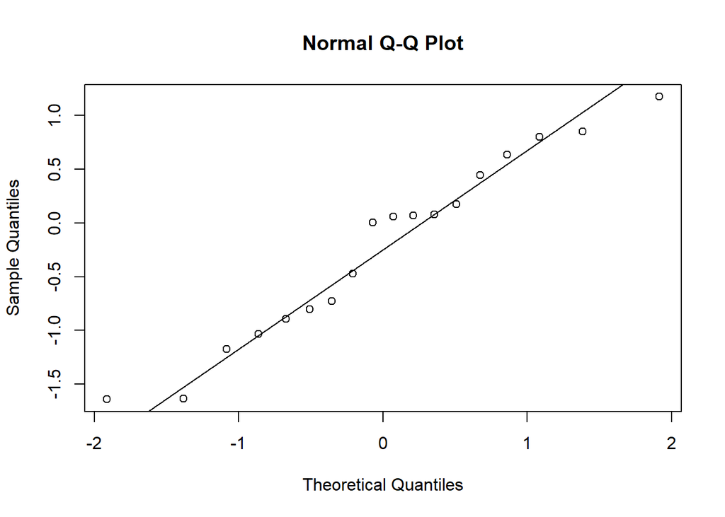

```r
qqnorm(residuals(glm(formula = PC.ug.cm2 ~ PE.ug.cm2, family = Gamma(link = "log"), data =
                       PEdetects)))
qqline(residuals(glm(formula = PC.ug.cm2 ~ PE.ug.cm2, family = Gamma(link = "log"), data =
                       PEdetects)))
```

```r
performance::r2(glm(formula = PC.ug.cm2 ~ PE.ug.cm2, family = Gamma(link = "log"), data =
                      PEdetects)) # R2 for Generalized Linear Regression
```

```
## # R2 for Generalized Linear Regression
##   Nagelkerke's R2: 0.681
```

```r
                                      #Nagelkerke's R2: 0.681

coef2<-coef(glm(formula = PC.ug.cm2 ~ PE.ug.cm2, family = Gamma(link = "log"), data = PEdetects))[2]
coef2 #expected to be linear, but not 1:1
```

```
## PE.ug.cm2
##  24.43307
```

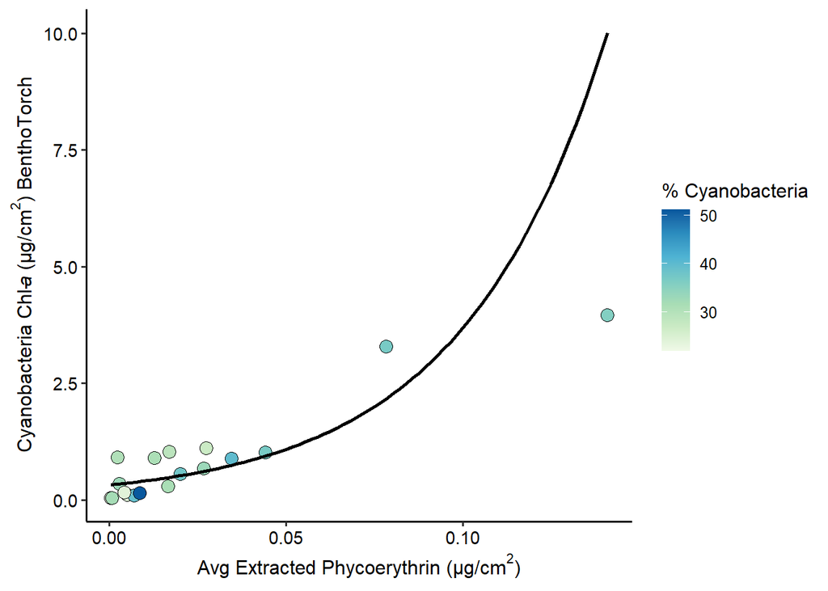

```r
#GLM > PE and PC for samples where PE was detected. Color by Percent Cyano on BT
ggsave("PC vs PE for PE detects, color by Percent Cyano on BT.pdf", width = 8, height = 5, units = "in")
ggplot(PEdetects, aes(x =PE.ug.cm2, y = PC.ug.cm2)) + geom_point(aes(fill = Perc.Cyano.BT), shape = 21, size = 3.5, color = "black") +
  scale_fill_distiller(palette = "GnBu", direction = 1) +
  geom_smooth(method = "glm", method.args = list(family = Gamma(link = "log")), se = FALSE, color = 'black', size = 1) + theme_classic2() +
  xlab(expression(paste("Avg Extracted Phycoerythrin (µg/cm" ^ "2" * ")"))) +
  ylab(expression(paste("Cyanobacteria Chl-",italic("a "),"(µg/cm" ^ "2" * ") BenthoTorch"))) +
  labs(fill = "% Cyanobacteria") + theme(axis.text = element_text(size = 11, color = "black"))
```

```r
dev.off()
```

**Figure 3** Comparison of total Chl-a between BenthoTorch and in vitro fluorometry *Proof of concept*

```r
glm(formula = Chla.ug.cm2 ~ Sum.BT.Chla, family = Gamma(link = "log"), data = metadata)
```

```
##
## Call:  glm(formula = Chla.ug.cm2 ~ Sum.BT.Chla, family = Gamma(link = "log"),
##     data = metadata)
##
## Coefficients:
## (Intercept)  Sum.BT.Chla
##     -0.5218       0.7972
##
## Degrees of Freedom: 70 Total (i.e. Null);  69 Residual
##   (11 observations deleted due to missingness)
## Null Deviance:       93.55
## Residual Deviance: 52.77     AIC: 270.7
```

```r
summary(glm(formula = Chla.ug.cm2 ~ Sum.BT.Chla, family = Gamma(link = "log"), data =
              metadata))#highly significant relationship between extracted Chla and BT
```

```
##
## Call:
## glm(formula = Chla.ug.cm2 ~ Sum.BT.Chla, family = Gamma(link = "log"),
##     data = metadata)
##
## Coefficients:
##             Estimate Std. Error t value Pr(>|t|)
## (Intercept) -0.52178    0.18254  -2.858  0.00562 **
## Sum.BT.Chla  0.79716    0.08403   9.487  3.9e-14 ***
## ---
## Signif. codes:  0 '***' 0.001 '**' 0.01 '*' 0.05 '.' 0.1 ' ' 1
##
## (Dispersion parameter for Gamma family taken to be 0.7615697)
##
##     Null deviance: 93.546  on 70  degrees of freedom
## Residual deviance: 52.768  on 69  degrees of freedom
##   (11 observations deleted due to missingness)
## AIC: 270.71
##
## Number of Fisher Scoring iterations: 12
```

```r
                        #estimate of total Chla
residuals(glm(formula = Chla.ug.cm2 ~ Sum.BT.Chla, family = Gamma(link = "log"), data =
                metadata))
```

```
##            1            2            3            4            5            6
## -1.850182596 -1.038018715 -0.427373765 -1.201080274 -1.200279087 -1.476807921
##            7            8            9           10           11           12
## -0.942664721 -0.756756732  0.080721613 -0.467051596  0.451000844  0.128784301
##           13           14           15           17           18           19
##  0.158373242  0.601872333  0.509403989 -0.658419090 -1.346379651 -0.024528723
##           21           22           23           24           25           26
##  0.315514195  2.364899697 -0.371399457  0.277084292  0.017443697  0.806717240
##           27           28           29           30           31           33
## -0.036121159  0.194208609  1.113951314 -0.734512137 -1.010195148 -2.005568656
##           35           38           40           41           43           46
## -1.728089045 -1.067501965  0.605227363  0.702541810 -0.241606653  0.344052268
##           47           48           49           50           51           52
## -0.407929425  0.387601793  1.219086412  0.347685526  0.914458556  0.356207887
##           53           54           55           56           57           58
## -0.034072614  0.678883674  0.009573463 -0.716546530  0.120581474 -0.269557048
##           59           60           61           62           63           64
##  1.412056401 -0.634689121 -1.017345774 -1.247400871 -1.746640977  0.521250405
##           66           67           68           69           70           71
##  0.281562976  0.007017110 -1.337301739 -0.457692742 -0.424332136 -0.751850255
##           72           73           74           75           76           77
## -0.091941619 -1.172348383 -0.104964694 -0.459668439 -0.386808988 -0.227321759
##           78           79           80           81           82
## -1.236591216 -0.939615568  0.203770847  0.245386122  0.485806311
```

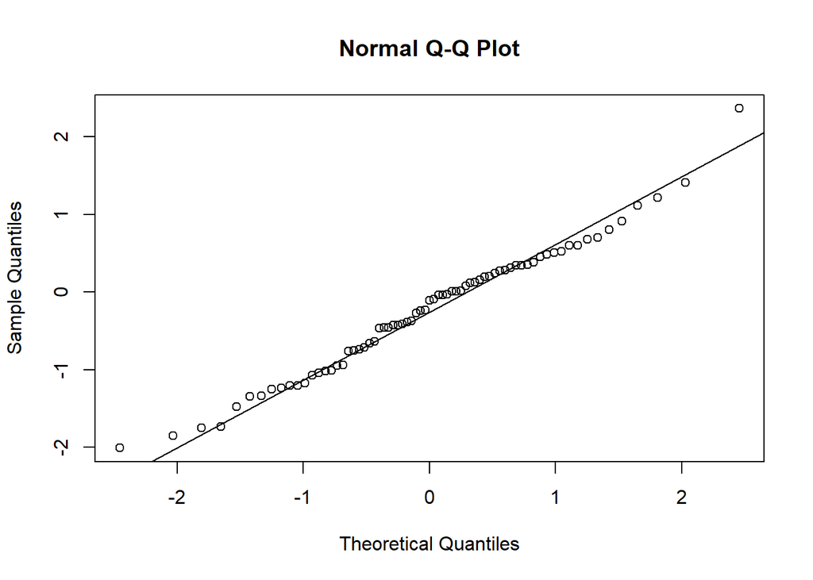

```r
qqnorm(residuals(glm(formula = Chla.ug.cm2 ~ Sum.BT.Chla, family = Gamma(link = "log"), data
                     = metadata)))
qqline(residuals(glm(formula = Chla.ug.cm2 ~ Sum.BT.Chla, family = Gamma(link = "log"), data
                     = metadata)))
```

```r
performance::r2(glm(formula = Chla.ug.cm2 ~ Sum.BT.Chla, family = Gamma(link = "log"), data =
                      metadata))# R2 for Generalized Linear Regression
```

```
## # R2 for Generalized Linear Regression
##   Nagelkerke's R2: 0.597
```

```r
                                     #Nagelkerke's R2: 0.597
F3slope<- coef(glm(formula = Chla.ug.cm2 ~ Sum.BT.Chla, family = Gamma(link = "log"), data = metadata))[2]
F3slope  #slope = 0.797
```

```
## Sum.BT.Chla
##   0.7971649
```

The exponential slope = 0.80, so e^0.8 = 2.23. This means that for every one unit increase in in BenthoTorch Chla, there was a 2.23 increase in fluorometric Chla (extracted).

```r
ggsave("Sum Chl-a comparison.pdf", width = 8, height = 5, units = "in")
```

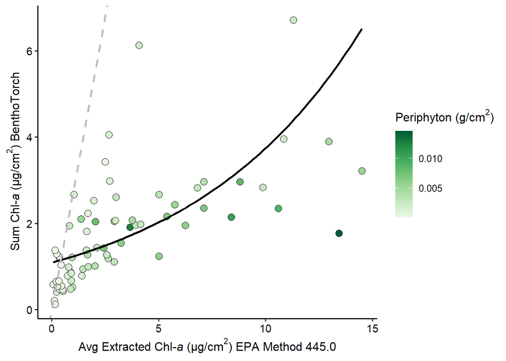

```r
ggplot(metadata, aes(x =Chla.ug.cm2, y = Sum.BT.Chla)) + geom_point(aes(fill = Mass.per.Area.Scraped.g.cm2), shape = 21, size = 3, color = "black") +
  scale_fill_distiller(palette = "Greens", direction = 1) +
  geom_smooth(method = "glm", method.args = list(family = Gamma(link = "log")), se = FALSE, color = 'black', size = 1)+ theme_classic2() +
  ylab(expression(paste("Sum Chl-",italic("a "),"(µg/cm" ^ "2" * ") BenthoTorch"))) +
  xlab(expression(paste("Avg Extracted Chl-",italic("a "), "(µg/cm" ^ "2" * ") EPA Method 445.0"))) +
  labs(fill = expression(paste("Periphyton (g/cm" ^ "2"* ")"))) + theme(axis.text = element_text(size = 11, color = "black")) + geom_abline(intercept = 0, slope = exp(1), color = "gray", linetype = "dashed", size = 1)
```

```r
dev.off()
```

**Figure 4** Cyano Chla from BenthoTorch and extracted PC. All samples

```r
glm(formula = PC.ug.cm2 ~ Cyano.Chla, family = Gamma(link = "log"), data = metadata)
```

```
##
## Call:  glm(formula = PC.ug.cm2 ~ Cyano.Chla, family = Gamma(link = "log"),
##     data = metadata)
##
## Coefficients:
## (Intercept)   Cyano.Chla
##      -1.703        1.457
##
## Degrees of Freedom: 80 Total (i.e. Null);  79 Residual
##   (1 observation deleted due to missingness)
## Null Deviance:       121.5
## Residual Deviance: 106.9     AIC: 36.42
```

```r
summary(glm(formula = PC.ug.cm2 ~ Cyano.Chla, family = Gamma(link = "log"), data =
              metadata))#this is a highly significant relationship
```

```
##
## Call:
## glm(formula = PC.ug.cm2 ~ Cyano.Chla, family = Gamma(link = "log"),
##     data = metadata)
##
## Coefficients:
##             Estimate Std. Error t value Pr(>|t|)
## (Intercept)  -1.7026     0.2196  -7.751 2.65e-11 ***
## Cyano.Chla    1.4573     0.2905   5.017 3.17e-06 ***
## ---
## Signif. codes:  0 '***' 0.001 '**' 0.01 '*' 0.05 '.' 0.1 ' ' 1
##
## (Dispersion parameter for Gamma family taken to be 1.373625)
##
##     Null deviance: 121.45  on 80  degrees of freedom
## Residual deviance: 106.94  on 79  degrees of freedom
##   (1 observation deleted due to missingness)
## AIC: 36.419
##
## Number of Fisher Scoring iterations: 14
```

```r
residuals(glm(formula = PC.ug.cm2 ~ Cyano.Chla, family = Gamma(link = "log"), data = metadata))
```

```
##           1           2           3           4           5           6
## -1.71055006 -1.24850999 -0.82905632 -0.87081606 -1.78602770 -1.85351750
##           7           8           9          10          11          12
## -1.67440384 -0.64927228 -0.09243785 -0.74980517 -0.10535959 -0.34990012
##          13          14          15          16          17          18
##  0.16935296  0.27278730  0.44030859 -1.11189329 -0.10568195 -1.47098667
##          19          20          21          22          23          24
## -0.76178689 -1.58207799  1.58692906  2.42985729  0.91589161 -0.88548789
##          25          26          27          28          29          30
##  0.65743219 -0.45252428 -0.03147507 -0.65296984 -0.19728128 -0.64527122
##          31          32          33          34          35          36
## -1.09704203 -1.64273485 -2.00208359 -2.35042639 -1.92736641 -2.15973032
##          37          38          39          40          41          42
## -1.88263117 -1.87153698 -1.11472704 -1.22807194 -0.45511499 -1.65951896
##          43          44          46          47          48          49
## -0.50525827 -1.85659645  0.08443974 -0.35041799  0.36478751  1.32353407
##          50          51          52          53          54          55
##  0.16355060  0.80555592  2.04962181  0.40527236  2.22195942  0.40299614
##          56          57          58          59          60          61
## -0.52163874  0.30294260 -0.42833798  1.69405767 -0.95965424 -1.09992525
##          62          63          64          65          66          67
## -0.44052417 -2.03251503 -0.71797178 -0.70796872  0.60213863  0.06510843
##          68          69          70          71          72          73
## -0.65740197 -0.64927184  0.68817860 -0.60817707  0.43865587 -1.56179569
##          74          75          76          77          78          79
## -0.72931407  1.29077936 -0.02861463  0.67924657 -0.80684503 -0.86135665
##          80          81          82
##  1.23516466  0.35281572  0.61607575
```

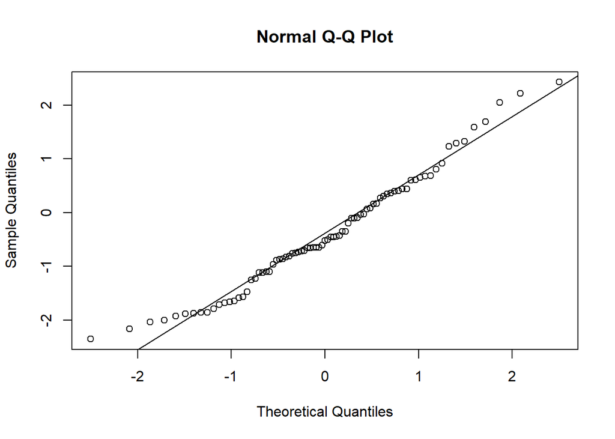

```r
qqnorm(residuals(glm(formula = PC.ug.cm2 ~ Cyano.Chla, family = Gamma(link = "log"), data =
                       metadata)))
qqline(residuals(glm(formula = PC.ug.cm2 ~ Cyano.Chla, family = Gamma(link = "log"), data =
                       metadata)))
```

```r
performance::r2(glm(formula = PC.ug.cm2 ~ Cyano.Chla, family = Gamma(link = "log"), data =
                      metadata))# R2 for Generalized Linear Regression
```

```
## # R2 for Generalized Linear Regression
##   Nagelkerke's R2: 0.211
```

```r
                                      #Nagelkerke's R2: 0.211
coef4<-coef(glm(formula = PC.ug.cm2 ~ Cyano.Chla, family = Gamma(link = "log"), data = metadata))[2]
coef4 #1.46 = exponential slope.
```

```
## Cyano.Chla
##   1.457307
```

PE-detects only

```r
glm(formula = PC.ug.cm2 ~ Cyano.Chla, family = Gamma(link = "log"), data = PEdetects)
```

```
##
## Call:  glm(formula = PC.ug.cm2 ~ Cyano.Chla, family = Gamma(link = "log"),
##     data = PEdetects)
##
## Coefficients:
## (Intercept)   Cyano.Chla
##      -1.857        2.325
##
## Degrees of Freedom: 17 Total (i.e. Null);  16 Residual
## Null Deviance:       26.88
## Residual Deviance: 19.92     AIC: 29.82
```

```r
summary(glm(formula = PC.ug.cm2 ~ Cyano.Chla, family = Gamma(link = "log"), data = PEdetects))#this is significant
```

```
##
## Call:
## glm(formula = PC.ug.cm2 ~ Cyano.Chla, family = Gamma(link = "log"),
##     data = PEdetects)
##
## Coefficients:
##             Estimate Std. Error t value Pr(>|t|)
## (Intercept)  -1.8573     0.5426  -3.423  0.00349 **
## Cyano.Chla    2.3251     0.7508   3.097  0.00693 **
## ---
## Signif. codes:  0 '***' 0.001 '**' 0.01 '*' 0.05 '.' 0.1 ' ' 1
##
## (Dispersion parameter for Gamma family taken to be 0.9990892)
##
##     Null deviance: 26.884  on 17  degrees of freedom
## Residual deviance: 19.918  on 16  degrees of freedom
## AIC: 29.823
##
## Number of Fisher Scoring iterations: 8
```

```r
residuals(glm(formula = PC.ug.cm2 ~ Cyano.Chla, family = Gamma(link = "log"), data = PEdetects))
```

```
##          1          2          3          4          5          6          7
## -0.6087076 -0.6124262 -1.6544182 -2.3343377 -1.7734840 -0.6367292 -0.0704446
##          8          9         10         11         12         13         14
##  0.8805347 -0.1749130  1.2436852 -0.1822407 -0.9567170 -0.3225406 -0.4495209
##         15         16         17         18
##  1.4806568 -0.8303075  0.1148141  0.9634320
```

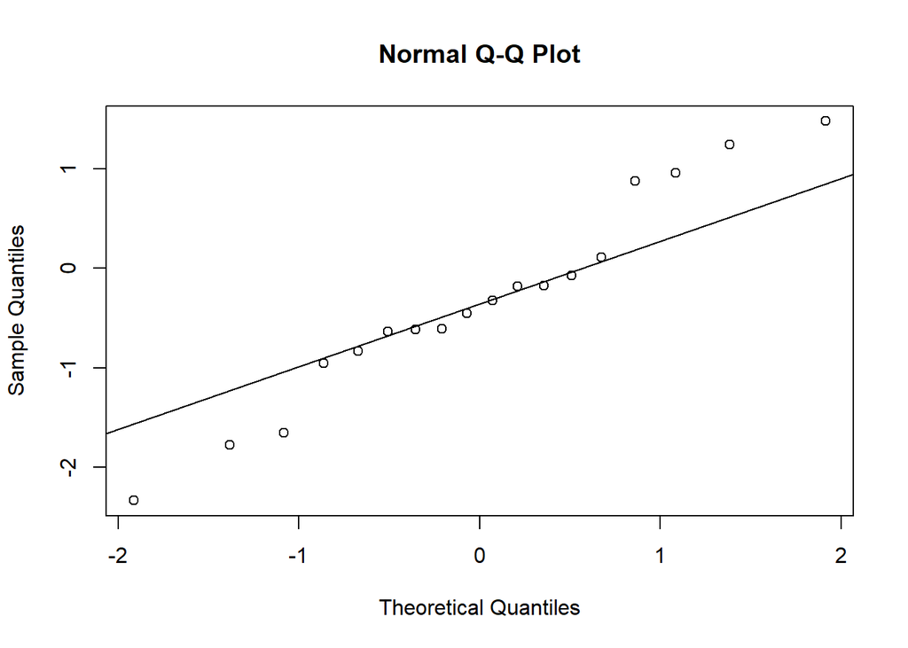

```r
qqnorm(residuals(glm(formula = PC.ug.cm2 ~ Cyano.Chla, family = Gamma(link = "log"), data =
                       PEdetects)))
qqline(residuals(glm(formula = PC.ug.cm2 ~ Cyano.Chla, family = Gamma(link = "log"), data =
                       PEdetects)))
```

```r
performance::r2(glm(formula = PC.ug.cm2 ~ Cyano.Chla, family = Gamma(link = "log"), data =
                      PEdetects))# R2 for Generalized Linear Regression
```

```
## # R2 for Generalized Linear Regression
##   Nagelkerke's R2: 0.414
```